# 06_QuantLing_Section

Eric Wilbanks

2/28/2020 - 3/02/2020

## 1. Goals for Section

1. General questions?
2. /str/ retraction data set
3. Hypotheses and Exploratory Visualizations
4. Interaction and Multiple Categorical Model
5. Releveling and Coefficients

## 2. Questions?

## 3. str data background

We’re going to be looking at a dataset that is modeled after my MA thesis (since Ethics restrictions prevent us from looking at the real data.)

We’re investigating how the pronunciation of words/phrases that contain “str”, like “street”, “construction”, and “this truck” are changing over time in Raleigh, N.C.

```
How do you all pronounce these words? Do you hear any differences from your classmates?
```

```
# Younger speakers in the US and elsewhere are starting to say [s] in <str> clusters more like "SH"

# This involves a decrease in spectral energy, and a lowering of the Center of Gravity (COG) of the fricative spectrum
```

The data set that I’ve simulated assumes that we’ve interviewed 2,000 Raleigh natives who were born between 1940 and 2000.

We then measure the Center of Gravity (COG) of all of their [s] before [tr] clusters (lower = more like “sh”, higher = more like “s”).

We also mark down whether they identified as male or female, and note that we haven’t encountered any self-identified non-binary or trans folx in our sample. (Ask me about gender and fricatives outside of class; it’s pretty complicated and interesting!).

```
Load and explore the dataset.

What are your suspicions about what the "position" variable could encode? Hint: it's linguistic.
```

```r
str_data <- read.csv('str_data.csv',header=T)
```

```
# position has three levels:
levels(str_data$position)
```

```
## [1] "final"   "initial" "medial"
```

```
# initial = beginning of word ("street")
# medial = word-internal ("construction")
# final = across word-boundaries ("this truck")
```

## 4. str data hypotheses

The first thing to do when you’re working on your analysis is make your hypotheses.

```
1.) What predicted effect (if any) would birthyear have on COG? (remember, lower = more like SH, higher = more like S)

2.) What predicted effect (if any) would gender have on COG?

3.) What predicted effect (if any) would position have on COG?

4.) Do you think any interactions would be motivated?
```

```
# Since it seems like <str> is becoming more like SH over time, we'd predict that as birthyear increases, COG would decrease

# It looks like women have a higher COG than men.

# Unclear what predictions we'd have about position a priori?

# The increase might be quicker for women than men, motivating an interaction. Unclear if position should be involved in any interaction.
```

## 5. str data visualization

Now let’s create the following plots:

1. boxplot or density plot of cog by gender
2. boxplot of density plot of cog by position
3. scatter plot of birthyear (x) and cog (y) with a geom_smooth(method=‘lm’)
4. scatterplot of birthyear (x) and cog (y), separated out for gender and position, with a geom_smooth(method=‘lm’)

```
Were our predictions borne out?
```

```
library(ggplot2)
ggplot(str_data, aes(gender,cog)) + geom_boxplot()
```

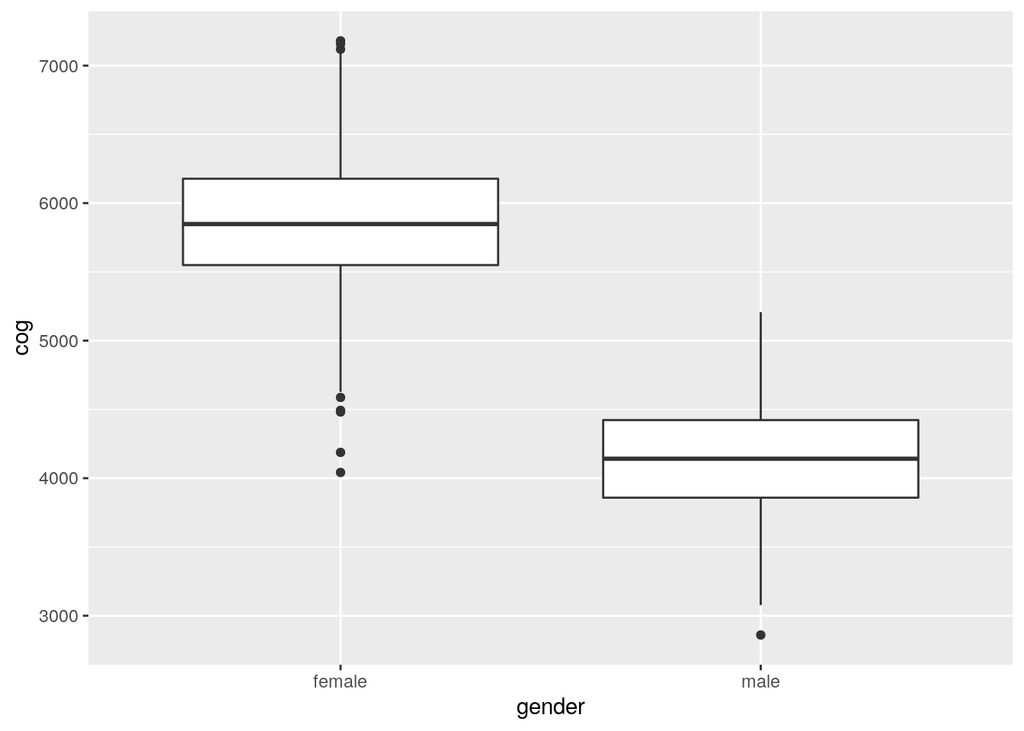

```
ggplot(str_data, aes(position,cog)) + geom_boxplot()
```

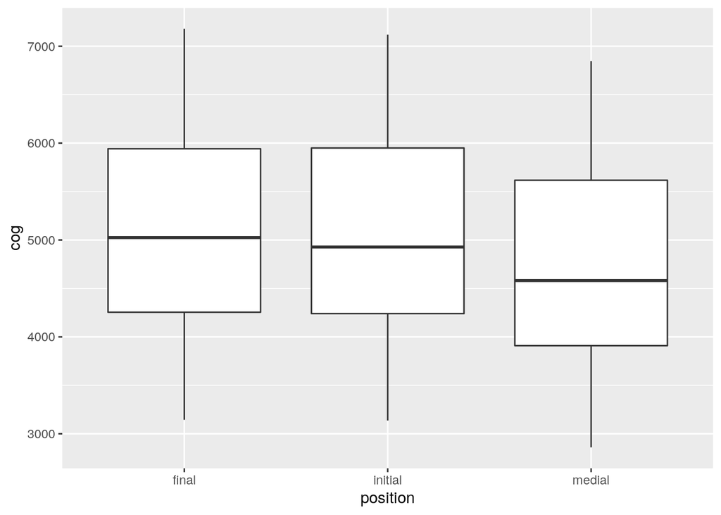

```
ggplot(str_data, aes(birthyear,cog)) + geom_point() + geom_smooth(method='lm')
```

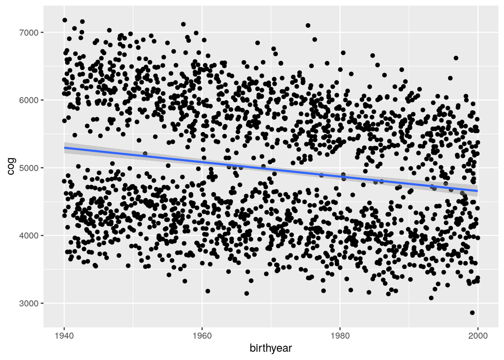

```
ggplot(str_data, aes(birthyear,cog,color=position)) + geom_point() + geom_smooth(method='lm') + facet_grid(~gender)
```

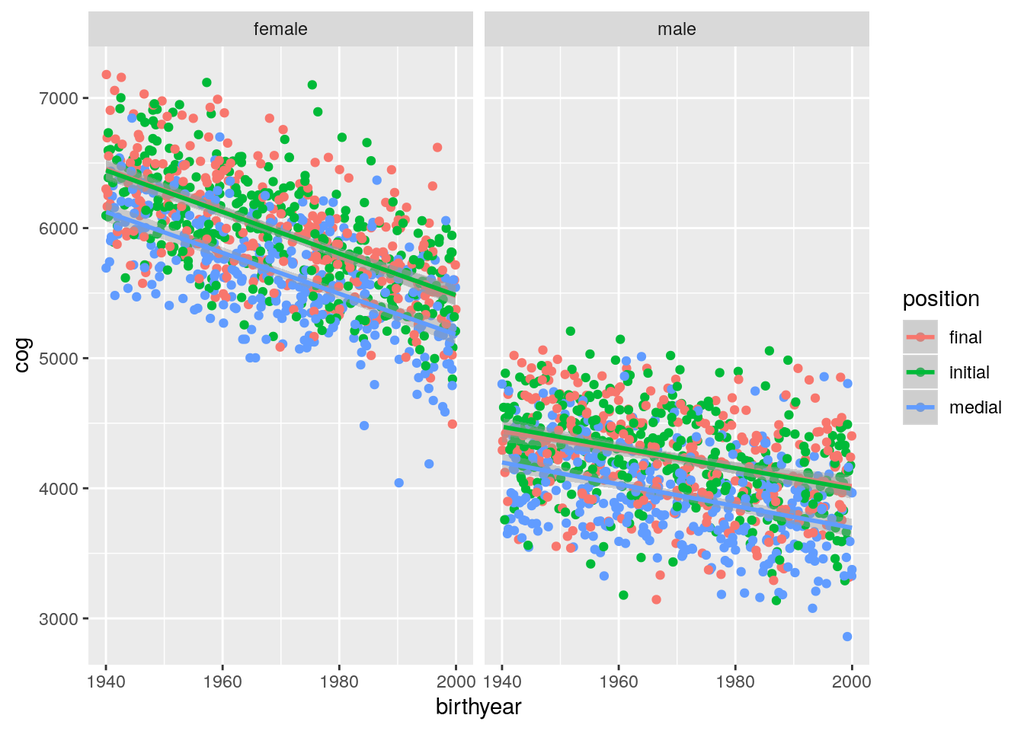

```
# It looks like our predictions were borne out

#it also appears that there's an effect of position, with medial position showing lower COG than other positions.
```

## 6. str data modeling

With our predictions in hand, let’s fit a linear model to the data and analyze the results. With your small groups:

1. fit the following models
2. compare model BIC (using the BIC() function); **which model is best?**

```
m1: dependent COG ~ birthyear and gender
m2: dependent COG ~ interaction between birthyear and gender
m3: dependent COG ~ position and interaction between birthyear and gender
m4: dependent COG ~ three-way interaction
```

```
library(lme4)
```

```
m1 <- lm(cog ~ birthyear + gender, str_data)
m2 <- lm(cog ~ birthyear * gender, str_data)
m3 <- lm(cog ~ birthyear * gender + position, str_data)
m4 <- lm(cog ~ birthyear * gender * position, str_data)

BIC(m1,m2,m3,m4)
```

```
##    df      BIC
## m1  4 29480.62
## m2  5 29418.90
## m3  7 29127.42
## m4 13 29171.15
```

```
# model 3 (without three-way interaction) is the best fitting because it has the lowest BIC.
```

```
What does each coefficient of the best-fitting model mean?
```

```
summary(m3)
```

```
##
## Call:
## lm(formula = cog ~ birthyear * gender + position, data = str_data)
##
## Residuals:
##      Min       1Q   Median       3Q      Max
## -1297.20  -239.86    -0.18   236.24  1225.56
##
## Coefficients:
##                        Estimate Std. Error t value Pr(>|t|)
## (Intercept)           3.750e+04  1.271e+03  29.497   <2e-16 ***
## birthyear            -1.601e+01  6.453e-01 -24.810   <2e-16 ***
## gendermale           -1.787e+04  1.771e+03 -10.087   <2e-16 ***
## positioninitial       2.760e+00  1.925e+01   0.143    0.886
## positionmedial       -2.956e+02  1.906e+01 -15.513   <2e-16 ***
## birthyear:gendermale  8.195e+00  8.994e-01   9.112   <2e-16 ***
## ---
## Signif. codes:  0 '***' 0.001 '**' 0.01 '*' 0.05 '.' 0.1 ' ' 1
##
## Residual standard error: 347.6 on 1994 degrees of freedom
## Multiple R-squared:  0.8706, Adjusted R-squared:  0.8703
## F-statistic:  2684 on 5 and 1994 DF,  p-value: < 2.2e-16
```

```
## (Intercept) - 3.750e+04
# When birthyear is 0, the speaker is a woman, and the token occurs word-finally, the COG will be 37,500.

# This is essentially meaningless because birthyear in our sample can't be 0.


## birthyear - -16.01
# for each year increase for women, the COG decreases 16.

## gendermale - -1.787e+04
# when birthyear is 0, the intercept for men is 17,870 COG lower than women (their intercept is 19630).
# again, this is meaningless since birthyear can't equal 0

## positioninitial - 2.760
# the mean for initial position is 2.8 COG higher than final position
# this dif. is not significant

## positionmedial - -2.956e+02
# the mean for medial position is 295.6 COG lower than final position
# this dif. is signficant

## birthyear:gendermale
# To adjust the female slope of birthyear (-16 per year) for men, add 8.2 to it
# men's slope of birthyear is -7.8
```

## 7. str data model re-leveling

Looking at our best-fitting model, let’s look at what happens to the coefficients (and t-values) for the `position` variable

1. **Mark down the coefficients** for the default level comparisons of position.
2. Using the relevel() function, mark down the coefficients for all comparisions for **the remaining reference levels** of position.
3. **Create a diagram** (on paper/the board) that shows the relationship between comparison coefficients and reference levels.

```
# original and releveled models
m3 <- lm(cog ~ birthyear * gender + position, str_data)
m3b <- lm(cog~birthyear * gender + relevel(position,"initial"), str_data)
m3c <- lm(cog~birthyear * gender + relevel(position,"medial"), str_data)

# extract position coefficients and convert them into vectors of the right shape
c_final_ref <- c(0,unname(m3$coefficients[4:5]))
c_initial_ref <- c(unname(m3b$coefficients[4]),0,unname(m3b$coefficients[5]))
c_medial_ref <- c(unname(m3c$coefficients[4:5]),0)

# create matrix from vectors
c_mat <- cbind(c_final_ref,c_initial_ref,c_medial_ref)

# change matrix row/column names
rownames(c_mat) <- c('final','initial','medial')
colnames(c_mat) <- c('final_ref','initial_ref','medial_ref')

c_mat
```

```
##           final_ref initial_ref medial_ref
## final      0.000000   -2.759513   295.6307
## initial    2.759513    0.000000   298.3902
## medial  -295.630658 -298.390171     0.0000
```